# Looking for Philosophy on Wikipedia

There is an old sayin' that state that *"all roads lead to Rome"*. In our modern era, as means of communication tend to be digitalized, it has been replaced by the fact that all Wikipedia pages lead to the Wikipedia page about Philosophy. There is even a Wikipedia [page](https://en.wikipedia.org/wiki/Wikipedia:Getting_to_Philosophy) about this phenomenon (so meta !).

My goal in this toy project is to check if that is true (for Wikipedia, not for Rome !). To investigate, I will scrape Wikipedia pages using [Scrapy](https://scrapy.org/). I'm a big fan of web scrapping, but I've never used this framework before. I generally rely on BeautifulSoup and Request, and/or Selenium if needed. I will then analyze the relationship between pages with [Networkx](https://networkx.org/), a popular package for manipulating graph.

Let's start by importing the libraries.

```python
import scrapy
from scrapy.crawler import CrawlerProcess
import pandas as pd
import matplotlib.pyplot as plt
import networkx as nx
import logging, sys

logging.disable(sys.maxsize) # Disable logs from the notebook (to avoid Scrapy numerous ones)
```

## Collecting the data

The Scrapy framework is based on **spiders**, these are the ones who will actually crawl the web for you. To generate these spiders, you will have to create a class that inherits from the Spider class of Scrapy. It might look complicated at first glance, especially for those who are not familiar with object oriented programming (OOP), but believe me : it is not. You only need to implement 1 attribute (its name) and 2 methods (even 1 if your project is simple), and that's all !

The methods are where the magic happens : this is where you define the behavior that you expect from your spiders. I will not dive deeply into how to set your spider - this is not a tutorial for Scrapy (there are already plenty of good ones) - but here is a quick description of the main methods you need :

- _start*requests* lets you define which site you want to start crawling from. This method is not even mandatory : you can replace it by a list of urls (named _start*urls*). For this toy project, I use this method as I want to crawl repeatedly the same URL : the "random page" URL. This enables me to have a random sample of url pages as I don't want to spend a few days scrolling the entire Wikipedia website. Note that Scrapy is clever enough to not crawl a URL it has already visited. I use the parameter _dont*filter* to avoid this behavior for the "random page" (which is just an URL redirection).
- *parse* is used to - wait for it... - parse the pages that your spider crawl. This is where you collect the information you want, using CSS selectors or XPath. As you can see below, I'm using a css selector to get the first link of the page (more on this later). I store it in a dictionnary with the url of the current page. This method calls then the next url to parse using *follow* method.

I will begin with a sample of 1000 random Wikipedia pages. Note that these draws will be *with* replacement, even if it is highly unlikely to get twice the same web page given the population (the entire Wikipedia website).

```python
N_SAMPLES = 10**3
```

```python
class WikiSpider(scrapy.Spider):
    name = "wiki"

    def start_requests(self):
        url = 'https://en.wikipedia.org//wiki/Special:Random'
        for i in range(N_SAMPLES):
            yield scrapy.Request(url = url, callback = self.parse, dont_filter = True)

    def parse(self, response):
        first_link = response.css("div.mw-parser-output>p>a::attr(href)").get()
        yield {"wiki_page" : response.url,
               "first_link" : first_link}

        yield response.follow(url = first_link, callback = self.parse)
```

I chose to store the data collected in a csv file.

```python
process = CrawlerProcess(settings={
    'FEED_FORMAT': 'csv',
    'FEED_URI': 'items.csv'
})

process.crawl(WikiSpider)
process.start()
```

## Cleaning the data

As we saw earlier, the data has been stored in a cssv file in our working directory. Let's load it and inspect it.

```python
df_links = pd.read_csv("items.csv")
```

```python
df_links.info()
```

```
<class 'pandas.core.frame.DataFrame'>
RangeIndex: 1930 entries, 0 to 1929
Data columns (total 2 columns):
 #   Column      Non-Null Count  Dtype
---  ------      --------------  -----
 0   wiki_page   1930 non-null   object
 1   first_link  1916 non-null   object
dtypes: object(2)
memory usage: 30.3+ KB
```

We can see that there are some missing values for the field "first_link" : is it something wrong with our css selector ? Or is it possible that some Wikipedia pages may not have any link in their content ? Let's have a look at these pages.

```python
print(
    "There are ",
    df_links[df_links["first_link"].isna()].shape[0],
    "pages without first link",
    "(" + str(round(df_links[df_links["first_link"].isna()].shape[0] / df_links.shape[0],2)*100) + "%)"
    )

df_links[df_links["first_link"].isna()].head()
```

```
There are  14 pages without first link (1.0%)
```

|  | wiki_page | first_link |
| --- | --- | --- |
| 8 | https://en.wikipedia.org/wiki/Donofrio | NaN |
| 159 | https://en.wiktionary.org/wiki/method | NaN |
| 193 | https://en.wikipedia.org/wiki/List_of_Cash_Box... | NaN |
| 603 | https://en.wikipedia.org/wiki/List_of_defunct_... | NaN |
| 625 | https://en.wikipedia.org/wiki/1939_in_Ireland | NaN |

Well those pages have a specific design, and our CSS selector misses the spot. But as this represents only 1% of the pages, let's say it is good enough for this analysis and remove these unwanted values.

We will as well remove duplicates.

```python
df_clean = df_links[df_links["first_link"].notnull()].drop_duplicates()
```

To ease the reading, I will remove the first part of the link (the usual https://en.wikipedia.ect...) to keep only the title of the page

```python
df_clean = df_clean.apply(lambda x : x.str.split(pat = "/").str[-1])
df_clean.head()
```

|  | wiki_page | first_link |
| --- | --- | --- |
| 0 | V.R._Eaton_High_School | State_school |
| 1 | Front_de_lib%C3%A9ration_du_Qu%C3%A9bec | Marxism%E2%80%93Leninism |
| 2 | Foreign_relations_of_Japan | Ministry_of_Foreign_Affairs_(Japan) |
| 3 | Non-use_value | Public_goods |
| 4 | Poledno | Gmina_Bukowiec |

Let's check if Philosophy is indeed in this dataset :

```python
df_clean[df_clean["wiki_page"] == "Philosophy"].head()
```

|  | wiki_page | first_link |
| --- | --- | --- |
| 196 | Philosophy | Greek_language |

## Analysis

Alright ! Time to move on and to implement these edges in a NetworkX object. This will make the analysis much easier.

As the relations between pages have a direction (a web link goes only one way), it makes more sense to modelize this network as a directed graph, also known as digraph. NetworkX has a function to load edges from a pandas dataframe. We specify in this function that we want to generate a digraph using the parameter *create_using*.

```python
G = nx.from_pandas_edgelist(df_clean, source = "wiki_page", target = "first_link", create_using=nx.DiGraph)
print("The graph contains {} nodes (web pages) and {} edges (links)".format(len(G.nodes), len(G.edges)))
```

```
The graph contains 1959 nodes (web pages) and 1915 edges (links)
```

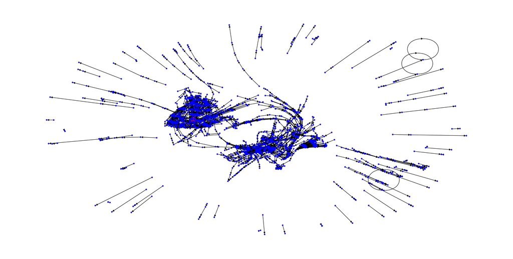

```python
plt.figure(figsize=(20,10))

node_color = ["red" if x == "Philosophy" else "blue" for x in G.nodes() ]
node_size = [200 if x == "Philosophy" else 10 for x in G.nodes() ]
nx.draw(G, node_color = node_color, node_size = node_size);
```

At first glance, we can clearly see that... this is quite a mess. NetworkX is limited for visualizations of large graphs, and it is preferable to use dedicated tool such as [Gephi](https://gephi.org/). But it is sufficient to see that there are clearly some nodes which are not connected to the Philosophy page, even if this node seems to be pretty well connected to the rest of the graph.

Let's see what are the predecessors of philosophy given all the nodes in this graph : we'll begin with the direct predecessors of the Philosophy page and go upstream to get their predecessors and so on.

```python
philo_predecessors = set()
queue = {*G.predecessors("Philosophy")}

while queue :
    current_node = queue.pop()
    philo_predecessors.add(current_node)

    node_predecessors = G.predecessors(current_node)
    if  node_predecessors:
        queue.update({x for x in node_predecessors if x not in philo_predecessors})

print("Philosophy has {} predecessors ({}% of nodes)".format(
    len(philo_predecessors),
    round(len(philo_predecessors) / len(G.nodes)*100))
    )
```

```
Philosophy has 1660 predecessors (85% of nodes)
```

Not bad ! Over 80% of Wikipedia pages in our sample leads to Philosophy, that's something !

But on the other hand, this means that all pages do **not** lead to this page. There are some "rebels".

```python
rebels = set(G.nodes).difference(philo_predecessors)
print("There are {} rebels like :\n{}, ...".format(len(rebels), ",\n".join(list(rebels)[0:5])))
```

```
There are 299 rebels like :
Strength_training,
Orientation_sensing,
Rock_the_40_Oz:_Reloaded,
List_of_United_Kingdom_locations,
International_Authority_for_the_Ruhr, ...
```

But wait, before wrapping up, something caught my eye : we saw earlier that the Philosophy page does have a link. This means that the world does not end on this page !

Replicating the same process we did to see its predecessors, let's find out the successors of Philosophy and see what can be more abstract than this concept.

```python
philo_successors = set()
queue = {*G.successors("Philosophy")}

while queue :
    current_node = queue.pop()
    philo_successors.add(current_node)

    node_successors = G.successors(current_node)
    if  node_successors:
        queue.update({x for x in node_successors if x not in philo_successors})

print("Philosophy has {} successors".format(
    len(philo_successors)
    ))
```

```
Philosophy has 12 successors
```

There are 12 pages after Philosophy. We will include them in a subgraph and plot them to see who they are.

```python
subgraph_nodes = philo_successors.union({"Philosophy"})
G_wiki = G.subgraph(philo_successors)
```

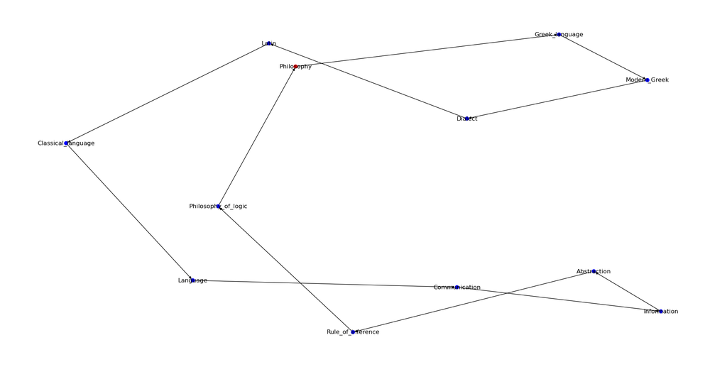

```python
plt.figure(figsize=(20,10))

node_color = ["red" if x == "Philosophy" else "blue" for x in G_wiki.nodes() ]
nx.draw(G_wiki,node_color = node_color, node_size = 50, with_labels=True);
```

We can see on this graph that there's a loop at the end of the world (of Wikipedia at least). And that a concept more abstract than Philosophy is ... Abstraction itself (I should have guessed).

## Conclusion

Well, to conclude, the answer is pretty easy : **no**, all Wikipedia pages do not lead to Philosophy. And even worse, Philosophy is not the end of the line ! But I can survive with that, and this was a nice way to discover a new tool for scrapping websites. Scrappy is not the most intuitive way to scrap in my humble opinion, but it is clearly a huge performer that need to be considered when looking to industrialize a scrapping process.